# Reproducible Research Assessment1

### Loading and preprocessing the data

1. Load the data (i.e. read.csv())
2. Process/transform the data (if necessary) into a format suitable for your analysis

```r
alldata <- read.csv("activity.csv", header = TRUE)
mydata <- alldata[!is.na(alldata$steps),]
```

### What is mean total number of steps taken per day?

1. Make a histogram of the total number of steps taken each day

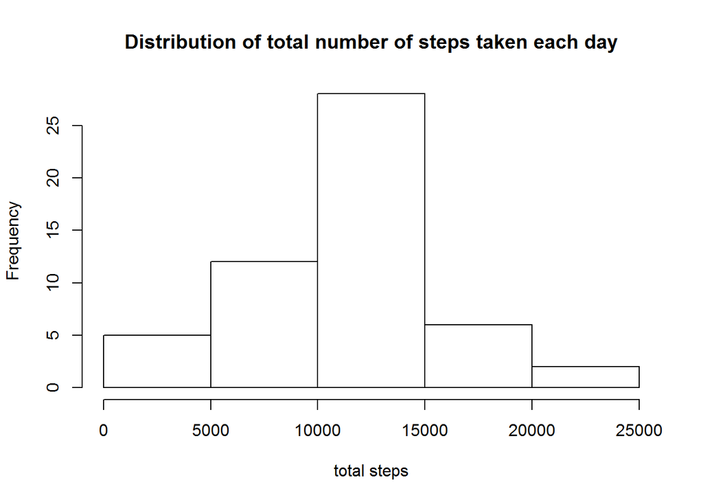

```r
library(plyr)
mytotal <- ddply(mydata, c("date"), summarize, totalsteps = sum(steps))
hist(mytotal$totalsteps, main="Distribution of total number of steps taken each day", xlab="total steps" )
```

```r
## the total number of steps taken each day
mytotal
```

```
##          date totalsteps
## 1  2012-10-02        126
## 2  2012-10-03      11352
## 3  2012-10-04      12116
## 4  2012-10-05      13294
## 5  2012-10-06      15420
## 6  2012-10-07      11015
## 7  2012-10-09      12811
## 8  2012-10-10       9900
## 9  2012-10-11      10304
## 10 2012-10-12      17382
## 11 2012-10-13      12426
## 12 2012-10-14      15098
## 13 2012-10-15      10139
## 14 2012-10-16      15084
```

[output cut: 39 more lines]

```r
mymedianmean <- ddply(mydata, c("date"), summarize, "meansteps" = mean(steps), "mediansteps"=as.numeric(median(steps)))

## Mean and Median
mymedianmean
```

```
##          date  meansteps mediansteps
## 1  2012-10-02  0.4375000           0
## 2  2012-10-03 39.4166667           0
## 3  2012-10-04 42.0694444           0
## 4  2012-10-05 46.1597222           0
## 5  2012-10-06 53.5416667           0
## 6  2012-10-07 38.2465278           0
## 7  2012-10-09 44.4826389           0
## 8  2012-10-10 34.3750000           0
## 9  2012-10-11 35.7777778           0
## 10 2012-10-12 60.3541667           0
## 11 2012-10-13 43.1458333           0
## 12 2012-10-14 52.4236111           0
## 13 2012-10-15 35.2048611           0
## 14 2012-10-16 52.3750000           0
```

[output cut: 39 more lines]

### What is the average daily activity pattern?

1. Make a time series plot (i.e. type = “l”) of the 5-minute interval (x-axis) and the average number of steps taken, averaged across all days (y-axis)
2. Which 5-minute interval, on average across all the days in the dataset, contains the maximum number of steps?

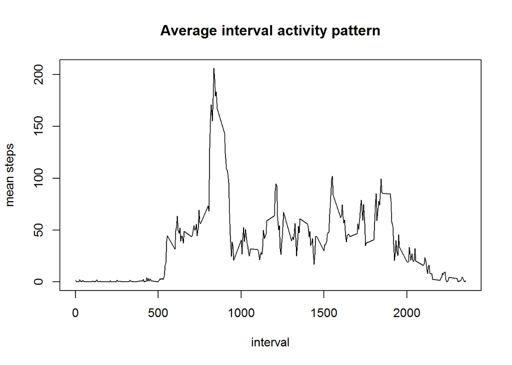

```r
intervalMean <- ddply(mydata, c("interval"), summarize, meansteps = mean(steps))

plot(intervalMean$interval, intervalMean$meansteps, type="l", main = "Average interval activity pattern", xlab = "interval", ylab="mean steps")
```

```r
maxsteps <- intervalMean[which(intervalMean$meansteps == max(intervalMean$meansteps)),]
##maximum number of steps
maxsteps
```

```
##     interval meansteps
## 104      835  206.1698
```

### Imputing missing values

1. Calculate and report the total number of missing values in the dataset (i.e. the total number of rows with NAs)

```r
totalnumberofmissing <- nrow(alldata) - nrow(na.omit(alldata))

##total number of missing
totalnumberofmissing
```

```
## [1] 2304
```

2. Devise a strategy for filling in all of the missing values in the dataset. The strategy does not need to be sophisticated. For example, you could use the mean/median for that day, or the mean for that 5-minute interval, etc.
3. Create a new dataset that is equal to the original dataset but with the missing data filled in.

```r
## filling in all of the missing values with the mean for that 5-minute interval

myfun <- function(x) replace(x, is.na(x), mean(x, na.rm = TRUE))

## new dataset with the mean for that 5-minute interval
alldata1 <- ddply(alldata, ~ interval, transform, steps = myfun(steps))
```

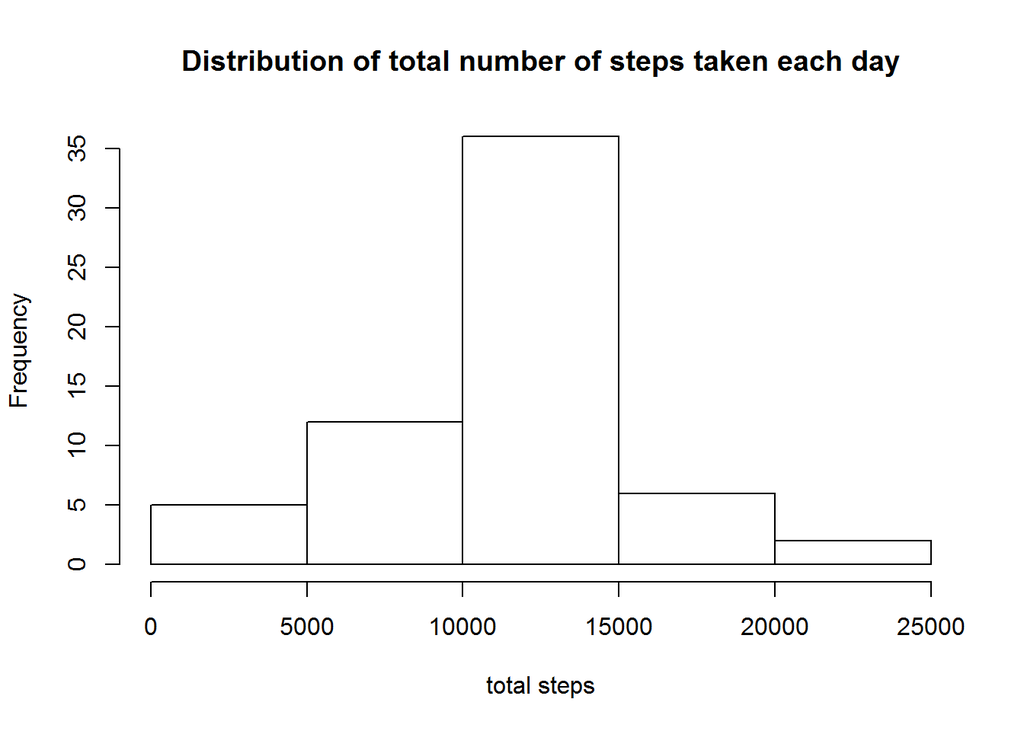

```r
mytotal2 <- ddply(alldata1, c("date"), summarize, totalsteps = sum(steps))
hist(mytotal2$totalsteps, main="Distribution of total number of steps taken each day", xlab="total steps" )
```

### Are there differences in activity patterns between weekdays and weekends?

1. Create a new factor variable in the dataset with two levels - “weekday” and “weekend” indicating whether a given date is a weekday or weekend day.
2. Make a panel plot containing a time series plot (i.e. type = “l”) of the 5-minute interval (x-axis) and the average number of steps taken, averaged across all weekday days or weekend days (y-axis). See the README file in the GitHub repository to see an example of what this plot should look like using simulated data.

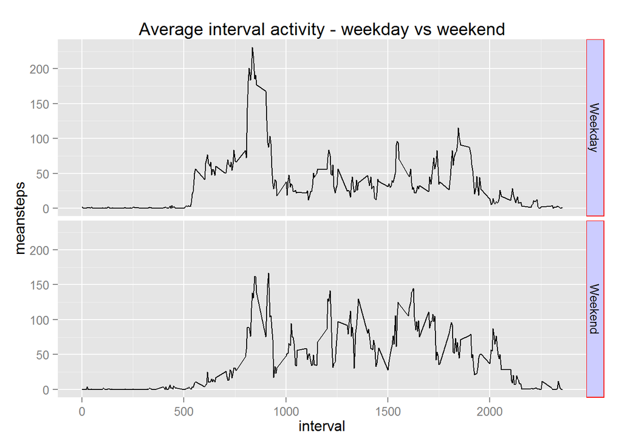

```r
alldata1$wend <- as.factor(ifelse(weekdays(as.Date(alldata1$date)) %in% c("Saturday","Sunday"), "Weekend", "Weekday"))

intervalMean2 <- ddply(alldata1, c("interval", "wend" ), summarize, meansteps = mean(steps))

library(ggplot2)
g <- ggplot(intervalMean2, aes(interval, meansteps), facets = . ~ wend, type="l", xlab = "interval", ylab="mean steps")
g <- g + geom_line()
g <- g + facet_grid(wend ~ .)
g <- g + labs(title = "Average interval activity - weekday vs weekend")
g <- g + theme(strip.text.x = element_text(size=8, angle=75),
               strip.background = element_rect(colour="red", fill="#CCCCFF"))

##save to a file
##ggsave(filename="AverageIntervalWeek.png", plot=g)
print(g)
```